# Einführung zu tidygraph

Philipp Mendoza

20. Oktober 2021

Ähnlich wie in Python stützen sich viele R Analysen auf zusätzliche Packages. In unserem Kurs verwendenwir `tidyverse` für die Datenhandhabung, `tidygraph` + `igraph` für die Bearbeitung von Netzwerkdaten und `ggraph` für die Netzwerkvisualisierung (`networD3` ist ein Package für interaktive Netzwerke).

```r
# Fürs Data Wrangling
library("tidyverse")

# SNA  spezifisch
library("igraph") # https://cran.r-project.org/web/packages/igraph/igraph.pdf
library("tidygraph") # https://cran.r-project.org/web/packages/tidygraph/tidygraph.pdf
## SNA Visualisierung
library("ggraph") # https://cran.r-project.org/web/packages/ggraph/ggraph.pdf
```

### Von Daten zu Netzwerken

Bspw.: Von einer **Edgelist** (Kantenliste) zu einem Graph Objekt.

```r
# Global Variables
N <- 8
E <- 20
```

1. Wir definieren eine zufällig generierte Kantenliste mit E = 20 **Kanten** und Gewichtung für N = 8 **Knoten**.

```r
# Ich generiere den Zufälligen Datensatz
df <- data.frame(
  from = sample(
    LETTERS[1:N], # Ziehe aus diesem Vektor
    E, # 30 Elemente
    TRUE # mit Zurücklegen
  ),
  to = sample(LETTERS[1:N], E, TRUE),
  weight = runif(E) # 20 zufällige Zahlen zwischen 0 und 1
)
```

2. Wir Wandeln die Kantenliste in ein `tidygraph` **Graphobjekt** um.

Was steckt nun hinter dem tidygraph Objekt?

```r
graph1
```

```
## # A tbl_graph: 8 nodes and 20 edges
## #
## # A directed multigraph with 1 component
## #
## # Node Data: 8 × 1 (active)
##   name
##   <chr>
## 1 B
## 2 C
## 3 D
## 4 F
## 5 H
## 6 E
## # … with 2 more rows
## #
## # Edge Data: 20 × 3
##    from    to weight
##   <int> <int>  <dbl>
## 1     1     6  0.423
## 2     2     7  0.733
## 3     3     6  0.765
## # … with 17 more rows
```

Ein tidygraph Objekt besteht aus:

- **Node Data**: ein gewöhnlicher data frame mit Attributdaten zu den Knoten
- **Edge Data**: ein gewöhnlicher data frame mit Beziehungsdaten (hier: Gewicht)

> Für deskriptive Analysen reichen meist Edge Daten (Beziehungsdaten) aus. Viele spannende Datenanalysen zielen hingegen auf Daten die nicht in den Beziehungen sind (*reminder:* soziales Verhalten, Meinungen, etc.). Hierfür greifen wir auf die Attributdaten zurück.

Zu den Node Daten können wir beliebige Daten hinzufügen, bzw. diese wie gewohnt mit der `dplyr`/`tidyverse`Logik **manipulieren**. Allerdings müssen wir mit der Funktion `activate()` klarstellen dass wir uns auf die nodes beziehen.

```r
graph1 %>%
  activate(nodes) %>%
  mutate(
    group = sample(c("cool", "lame"), N, replace = T)
    ) -> # assignment Pfeile funktionieren auch am Ende!
graph1
```

Wir können mit Hilfe des igraph package die graph Daten auch in ein anderes gewohntes Format bringen: die Adjazentmatrix

```r
graph1 %>% igraph::as_adjacency_matrix()
```

```
## 8 x 8 sparse Matrix of class "dgCMatrix"
##   B C D F H E G A
## B . 1 . . . 1 2 1
## C . . . . . . 1 .
## D . 1 . . 1 1 1 1
## F 1 1 . . . . . .
## H . . . . . . 1 .
## E . . . 1 . . . 1
## G 1 . 1 . . 1 . .
## A . . . 1 . . . .
```

*Note:* Die obige Matrix ist eine s.g. *sparse matrix*. Die Punkte in der Matrix sind praktisch Nullen, verbrauchen jedoch weniger Speicher.

## 2 Mode Netzwerke

Mit `create_*` liefert tidygraph eine [kleine Auswahl](https://tidygraph.data-imaginist.com/reference/index.html#section-graph-creation) an klassischen Graphentypen. Hier im Beispiel: ein 2-mode Netzwerk. Da dieses Netzwerk jedoch ein ‘vollständiger Graph’ ist, sprich ein Graph in dem alle möglichen Beziehungen tatsächlich vorhanden sind, nehme ich eine Zufallsauswahl der Beziehungen vor.

```r
temp <-
  create_bipartite(n1 = N, n2 = N / 2) %>%
  activate(edges) %>%
  # randomisierte Gewichte werden hinzugefügt
  mutate(weight = runif(32)) %>%
  # ich sample 20 Kanten raus um den Graph etwas natürlicher werden zu lassen
  sample_n(20)
```

Für eine kurze Visualisierung verwenden wir ggraph => ggraph Folgt derselben Ebenen Logik wie ggplot, hierzu später mehr.

```
## Using `stress` as default layout
```

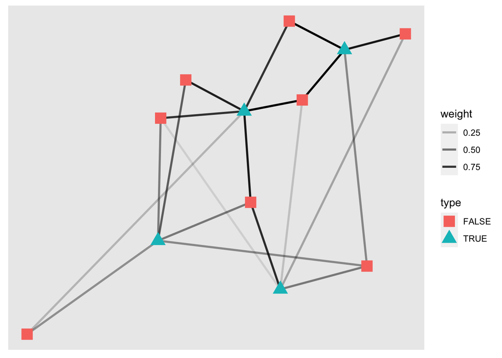

```r
temp %>%
  ggraph(weights = weight) +
  geom_edge_link(
    aes(alpha = weight),
    edge_width = 1
  ) +
  geom_node_point(aes(
    shape = type,
    color = type
  ), size = 5) +
  scale_shape_manual(values = c(15, 17)) # ich mag Quadrate
```

### Transformierung 2-mode ⇒ 1-mode

Für die transformierung eines bipartite / 2-mode graphen zu zwei verschiedenen 1-mode graphen. Brauchen wir erst die Inzidenz Matrix.

```r
incmat <- temp %>%
  as_incidence_matrix() %>%
  as.matrix()
```

Nun können wir über die Matritzenmultiplikation zu 2 unterschiedlichen Graphen kommen.

```r
a <- incmat %*% t(incmat)
b <- t(incmat) %*% incmat
```

Die nunmehr Adjazenzmatritzen lassen sich mit Kommentaren zu richtung und gewichtung wiederum leicht in ein graphobject umwandeln

```r
ga <- graph_from_adjacency_matrix(a,
                                  mode = "undirected",
                                  weighted = T) %>%
  as_tbl_graph()
gb <- graph_from_adjacency_matrix(b, mode = "undirected", weighted = T) %>%
  as_tbl_graph()
```

Schließlich haben wir zwei unterschiedliche Graphen:

```
## Using `stress` as default layout
```

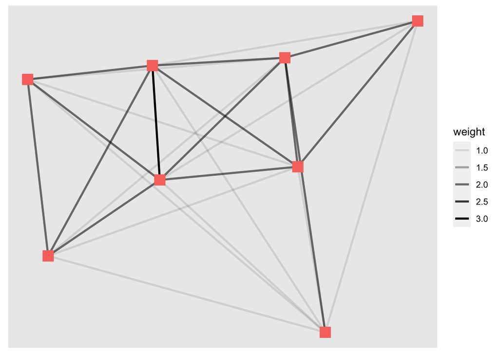

```r
ga %>%
  ggraph(weights = weight) +
  geom_edge_link(
    aes(alpha = weight),
    edge_width = 1
  ) +
  geom_node_point(size = 5, shape = 15, colour = "#F8766D")
```

```
## Using `stress` as default layout
```

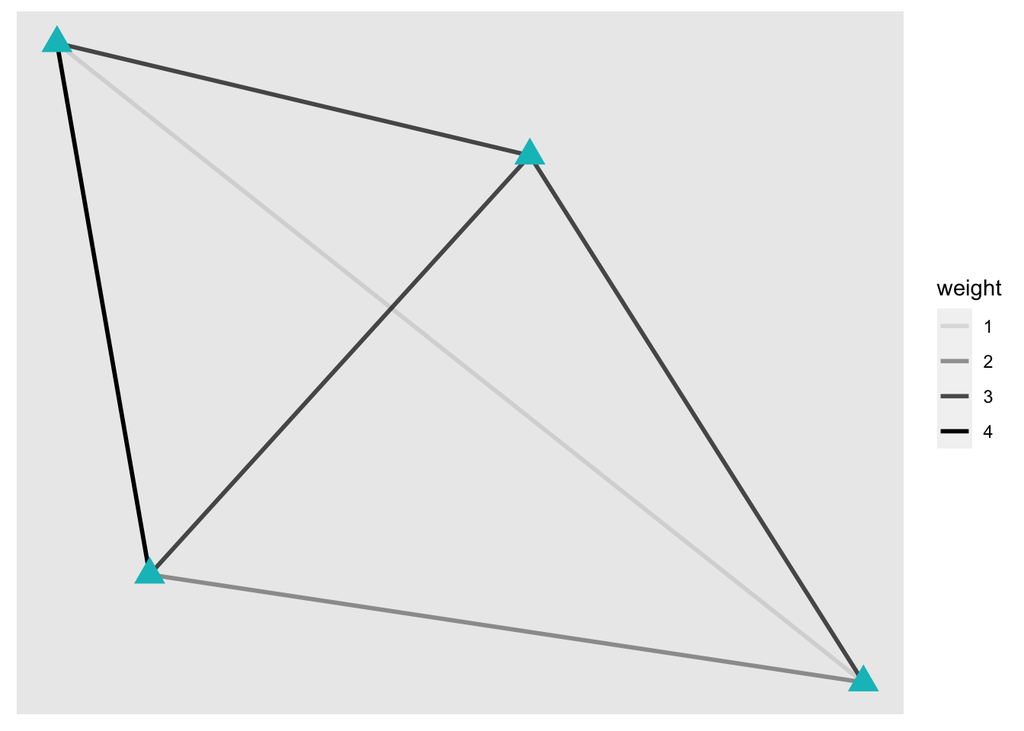

```r
gb %>%
  ggraph(weights = weight) +
  geom_edge_link(
    aes(alpha = weight),
    edge_width = 1
  ) +
  geom_node_point(size = 5, shape = 17, colour = "#00BFC4")
```

## Zentralitätsmaße

Zentralitätsmaße sind recht leicht berechenbar über `centrality_*`. Wir müssen hierbei immer überlegen ob wir bei der Berechnung die Richtung und Gewichtung miteinbeziehen wollen.

```r
ga <- ga %>%
  activate(nodes) %>%
  mutate(
    cent_close = centrality_closeness(weights = weight),
    cent_degree = centrality_degree(mode = "all")
  )
```

## Lokaler Clustering Koeffizient

Selbiges gilt für das lokale Clustering (hier: transitivity). Für eine Übersicht aller möglichen Parameter könnt ihr wiederum `?tidygraph` abrufen und dann bspw. auf ‘Index’ (ganz unten klicken).

```r
ga <- ga %>%
  activate(nodes) %>%
  mutate(
    local_clust = local_transitivity(weights=weight),
  )
```

## Visualisierung der neuen Parameter

### Entweder als normale Data Viz.

Hierfür extrahieren wir den Knoten / node data frame aus dem Graphobjekt

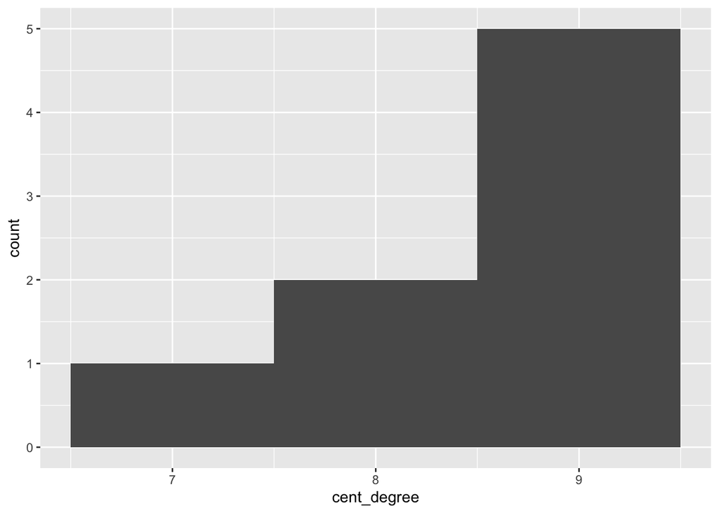

```r
ga %>%
  activate(nodes) %>%
  as_tibble %>%
  ggplot(aes(x=cent_degree)) +
  geom_histogram(binwidth = 1)
```

### Oder durch einen Netzwerkgraphen

```
## Using `stress` as default layout
```

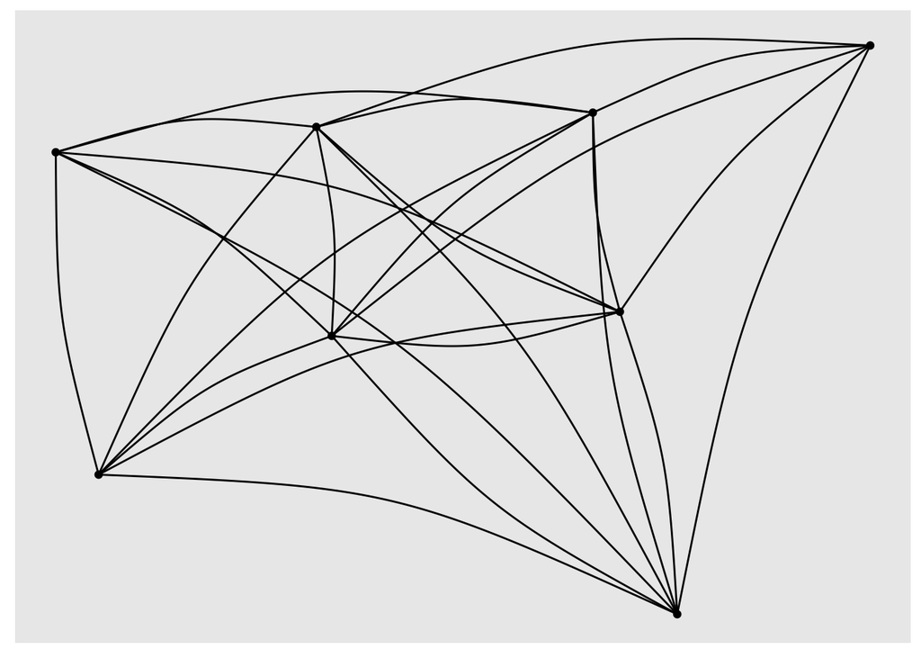

```r
ga %>%
  ggraph(weights = weight) +
  geom_edge_arc(strength=0.1) +
  geom_node_point()
```